# Quick Introduction

After all, Jupyter is essentially just an advanced word processor. There are two fairly prominent terms that you should notice, which are probably new to you: **cells** and **kernels** are key both to understanding Jupyter and to what makes it more than just a word processor. Fortunately, these concepts are not difficult to understand.

- A code cell contains code to be executed in the kernel and displays its output below.
- A Markdown cell contains text formatted using Markdown and displays its output in-place when it is run.

**Keyboard shortcuts**

- Run a cell with **Ctrl + Enter**
- Save the notebook with **Ctrl + s**
- Scroll up and down your cells with your Up and Down keys.
- Press A or B to insert a new cell above or below the active cell.
- M will transform the active cell to a Markdown cell.
- Y will set the active cell to a code cell.
- D + D (D twice) will delete the active cell.
- Z will undo cell deletion.
- Hold Shift and press Up or Down to select multiple cells at once.
- With multple cells selected, Shift + M will merge your selection.
- Ctrl + Shift + -, in edit mode, will split the active cell at the cursor.

For more info, please refer to **[Jupyter Notebook for Beginners](https://www.dataquest.io/blog/jupyter-notebook-tutorial/)**

# Markdown Text

## Texts and Comments

Markdown is a lightweight markup language with plain text formatting syntax. Its design allows it to be converted to many output formats. Markdown is often used to format readme files, for writing messages in online discussion forums, and to create rich text using a plain text editor.

Jupyter notebook uses markdown for text or comment addition. For basic markdown language usage, please refer to [Jupyter Notebook Documentation website](https://jupyter-notebook.readthedocs.io/en/stable/examples/Notebook/Working%20With%20Markdown%20Cells.html)

## Math Equations

Jupyter notebook uses MathJax to render LaTeX inside html/markdown. Just put your LaTeX math inside \$$ \$$. For example,

```python
$$c = \sqrt{a^2 + b^2}$$
```

$$c = \sqrt{a^2 + b^2}$$

Or use begin{} end{}

```python
\begin{align}
\dot{x} & = \sigma(y-x) \\
\dot{y} & = \rho x - y - xz \\
\dot{z} & = -\beta z + xy
\end{align}

\begin{equation*}
\left( \sum_{k=1}^n a_k b_k \right)^2 \leq \left( \sum_{k=1}^n a_k^2 \right) \left( \sum_{k=1}^n b_k^2 \right)
\end{equation*}
```

\begin{align} \dot{x} & = \sigma(y-x) \\ \dot{y} & = \rho x - y - xz \\ \dot{z} & = -\beta z + xy \end{align}\begin{equation*} \left( \sum_{k=1}^n a_k b_k \right)^2 \leq \left( \sum_{k=1}^n a_k^2 \right) \left( \sum_{k=1}^n b_k^2 \right) \end{equation*}

Or you can display LaTeX / Math output from Python

```python
from IPython.display import display, Math, Latex
display(Math(r'F(k) = \int_{-\infty}^{\infty} f(x) e^{2\pi i k} dx'))
```

$\displaystyle F(k) = \int_{-\infty}^{\infty} f(x) e^{2\pi i k} dx$

## Add Image or Picture

```python
You can use Markdown cell to display it by using the way of ![title](image location), like below
```

[figure not shown]

# Python Codes

The most common used python codes for data science projects are data frame functions, including data reading/loading, data writing, data selection, etc.

## Read/Load Data

```python
import numpy as np
import pandas as pd

df = pd.read_csv('../datasets/input_hot_skills.csv', encoding = "utf-8")
df.head(10)
```

|  | master_term | master_term_id | yearmo | month_no | skill_pos_cnt | total_pos_cnt | loop_no |
| --- | --- | --- | --- | --- | --- | --- | --- |
| 0 | Kubernetes | 121 | 201404 | 4 | 0 | 33323 | 53 |
| 1 | Stata | 214 | 201905 | 65 | 39 | 140823 | 88 |
| 2 | Selenium | 205 | 201502 | 14 | 250 | 89734 | 85 |
| 3 | Cisco Application Centric Infrastructure | 264 | 201705 | 41 | 3 | 119820 | 103 |
| 4 | Online Analytical Processing | 166 | 201903 | 63 | 55 | 123132 | 70 |
| 5 | Junit | 118 | 201710 | 46 | 438 | 128582 | 51 |
| 6 | Secret Security Clearance | 276 | 201610 | 34 | 29 | 95676 | 107 |
| 7 | SQL Server Reporting Services | 148 | 201405 | 5 | 87 | 31909 | 61 |
| 8 | Blockchain | 39 | 201704 | 40 | 0 | 104890 | 18 |
| 9 | Internal Auditor | 108 | 201901 | 61 | 130 | 122037 | 48 |

```python
# Show this dataframe's schema information
df.info()
```

```
<class 'pandas.core.frame.DataFrame'>
RangeIndex: 7169 entries, 0 to 7168
Data columns (total 7 columns):
master_term       7169 non-null object
master_term_id    7169 non-null int64
yearmo            7169 non-null int64
month_no          7169 non-null int64
skill_pos_cnt     7169 non-null int64
total_pos_cnt     7169 non-null int64
loop_no           7169 non-null int64
dtypes: int64(6), object(1)
memory usage: 392.2+ KB
```

## Data Selection

```python
df.loc[df['yearmo']==201705, ['yearmo','master_term', 'skill_pos_cnt']].head(10)
```

|  | yearmo | master_term | skill_pos_cnt |
| --- | --- | --- | --- |
| 3 | 201705 | Cisco Application Centric Infrastructure | 3 |
| 55 | 201705 | Golang | 57 |
| 67 | 201705 | ASP.NET | 705 |
| 71 | 201705 | Ruby | 483 |
| 158 | 201705 | Outlook | 3380 |
| 331 | 201705 | IBM Notes | 0 |
| 344 | 201705 | JCL | 130 |
| 366 | 201705 | WildFly | 643 |
| 367 | 201705 | Switching and Routing | 264 |
| 436 | 201705 | AWS Cloud | 510 |

## Add New Column

```python
df['year_no'] = df['yearmo'].astype(str).str.slice(0, 4)
df.head(10)
```

|  | master_term | master_term_id | yearmo | month_no | skill_pos_cnt | total_pos_cnt | loop_no | year_no |
| --- | --- | --- | --- | --- | --- | --- | --- | --- |
| 0 | Kubernetes | 121 | 201404 | 4 | 0 | 33323 | 53 | 2014 |
| 1 | Stata | 214 | 201905 | 65 | 39 | 140823 | 88 | 2019 |
| 2 | Selenium | 205 | 201502 | 14 | 250 | 89734 | 85 | 2015 |
| 3 | Cisco Application Centric Infrastructure | 264 | 201705 | 41 | 3 | 119820 | 103 | 2017 |
| 4 | Online Analytical Processing | 166 | 201903 | 63 | 55 | 123132 | 70 | 2019 |
| 5 | Junit | 118 | 201710 | 46 | 438 | 128582 | 51 | 2017 |
| 6 | Secret Security Clearance | 276 | 201610 | 34 | 29 | 95676 | 107 | 2016 |
| 7 | SQL Server Reporting Services | 148 | 201405 | 5 | 87 | 31909 | 61 | 2014 |
| 8 | Blockchain | 39 | 201704 | 40 | 0 | 104890 | 18 | 2017 |
| 9 | Internal Auditor | 108 | 201901 | 61 | 130 | 122037 | 48 | 2019 |

## Data Profiling

```python
# pandas-profiling for data profiling and quality assessment
import pandas_profiling

pandas_profiling.ProfileReport(df.reset_index(drop=True))
```

[output not shown]

[interactive chart not shown]

## Python Visualization

Visualizaiton can usually be done with Python matplotlib, seaborn or/and other libraries or R ggplot or ggplot2

### Load Matplotlib and Basic Setup

```python
# Matplotlib and seaborn for visualization
import matplotlib.pyplot as plt
import matplotlib as mpl

# Set up matplotlib environment
%matplotlib inline
mpl.rcParams['font.size'] = 10
mpl.rcParams['figure.figsize'] = (5, 5)

from IPython.core.pylabtools import figsize
```

### Plot Drawing

In this section, we want to show a trending plot about the skill of "Kubernetes" count.

```python
df1 = df.loc[df['master_term']=='Kubernetes', ['year_no', 'master_term', 'skill_pos_cnt']]
df1.head(10)
```

|  | year_no | master_term | skill_pos_cnt |
| --- | --- | --- | --- |
| 0 | 2014 | Kubernetes | 0 |
| 124 | 2018 | Kubernetes | 194 |
| 199 | 2018 | Kubernetes | 121 |
| 202 | 2019 | Kubernetes | 54 |
| 248 | 2019 | Kubernetes | 314 |
| 348 | 2018 | Kubernetes | 209 |
| 397 | 2019 | Kubernetes | 585 |
| 493 | 2014 | Kubernetes | 0 |
| 808 | 2014 | Kubernetes | 0 |
| 1003 | 2014 | Kubernetes | 0 |

Sum of skill count for Kubernetes with group by on every year

```python
df1 = df1.groupby(['year_no']).sum()
df1.sort_index(inplace=True)
df1.head(10)
```

| year_no | skill_pos_cnt |
| --- | --- |
| 2014 | 0 |
| 2015 | 94 |
| 2016 | 208 |
| 2017 | 954 |
| 2018 | 2823 |
| 2019 | 2628 |

Show the trending plot for Kubernetes skill

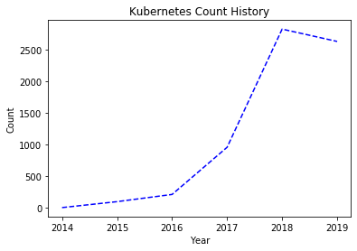

```python
plt.plot(df1, color='blue', linestyle='--')
plt.xlabel('Year')
plt.ylabel('Count')
plt.title('Kubernetes Count History')
```

Another way to plot

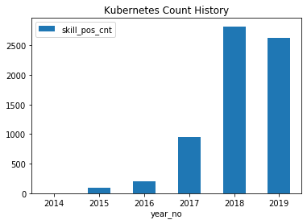

```python
df1.plot.bar(rot=0, title='Kubernetes Count History')
```

# Pyspark Codes

## Initialize Pyspark Context

```python
import findspark
findspark.init()
import pyspark

sc = pyspark.SparkContext(appName = 'Demo')
```

## Read/Load Data

```python
from pyspark import SQLContext
import os

sqlContext = SQLContext(sc)

if os.path.exists('../datasets/input_hot_skills.csv'):
    sample_df = sqlContext.read.csv('../datasets/input_hot_skills.csv', inferSchema=True, header=True)
    sample_df.show(10)
    sample_df.printSchema()
else:
    print('CSV File Doesnot Exist!')
```

```
+--------------------+--------------+------+--------+-------------+-------------+-------+
|         master_term|master_term_id|yearmo|month_no|skill_pos_cnt|total_pos_cnt|loop_no|
+--------------------+--------------+------+--------+-------------+-------------+-------+
|          Kubernetes|           121|201404|       4|            0|        33323|     53|
|               Stata|           214|201905|      65|           39|       140823|     88|
|            Selenium|           205|201502|      14|          250|        89734|     85|
|Cisco Application...|           264|201705|      41|            3|       119820|    103|
|Online Analytical...|           166|201903|      63|           55|       123132|     70|
|               Junit|           118|201710|      46|          438|       128582|     51|
|Secret Security C...|           276|201610|      34|           29|        95676|    107|
|SQL Server Report...|           148|201405|       5|           87|        31909|     61|
|          Blockchain|            39|201704|      40|            0|       104890|     18|
|    Internal Auditor|           108|201901|      61|          130|       122037|     48|
+--------------------+--------------+------+--------+-------------+-------------+-------+
only showing top 10 rows

root
 |-- master_term: string (nullable = true)
 |-- master_term_id: integer (nullable = true)
 |-- yearmo: integer (nullable = true)
 |-- month_no: integer (nullable = true)
 |-- skill_pos_cnt: integer (nullable = true)
 |-- total_pos_cnt: integer (nullable = true)
 |-- loop_no: integer (nullable = true)
```

## Data Selection

```python
sample_df.select('yearmo','master_term', 'skill_pos_cnt')\
    .filter(sample_df.yearmo == 201705)\
    .show(10)
```

```
+------+--------------------+-------------+
|yearmo|         master_term|skill_pos_cnt|
+------+--------------------+-------------+
|201705|Cisco Application...|            3|
|201705|              Golang|           57|
|201705|             ASP.NET|          705|
|201705|                Ruby|          483|
|201705|             Outlook|         3380|
|201705|           IBM Notes|            0|
|201705|                 JCL|          130|
|201705|             WildFly|          643|
|201705|Switching and Rou...|          264|
|201705|           AWS Cloud|          510|
+------+--------------------+-------------+
only showing top 10 rows
```

## Add New Column

```python
sample_df.withColumn('year_no', sample_df.yearmo.substr(0,4)).show(10)
```

```
+--------------------+--------------+------+--------+-------------+-------------+-------+-------+
|         master_term|master_term_id|yearmo|month_no|skill_pos_cnt|total_pos_cnt|loop_no|year_no|
+--------------------+--------------+------+--------+-------------+-------------+-------+-------+
|          Kubernetes|           121|201404|       4|            0|        33323|     53|   2014|
|               Stata|           214|201905|      65|           39|       140823|     88|   2019|
|            Selenium|           205|201502|      14|          250|        89734|     85|   2015|
|Cisco Application...|           264|201705|      41|            3|       119820|    103|   2017|
|Online Analytical...|           166|201903|      63|           55|       123132|     70|   2019|
|               Junit|           118|201710|      46|          438|       128582|     51|   2017|
|Secret Security C...|           276|201610|      34|           29|        95676|    107|   2016|
|SQL Server Report...|           148|201405|       5|           87|        31909|     61|   2014|
|          Blockchain|            39|201704|      40|            0|       104890|     18|   2017|
|    Internal Auditor|           108|201901|      61|          130|       122037|     48|   2019|
+--------------------+--------------+------+--------+-------------+-------------+-------+-------+
only showing top 10 rows
```

## SQL Codes in Pyspark

```python
sample_df.registerTempTable('sample_table')
sqlContext.sql('select * from sample_table order by yearmo desc').show(10)
```

```
+--------------------+--------------+------+--------+-------------+-------------+-------+
|         master_term|master_term_id|yearmo|month_no|skill_pos_cnt|total_pos_cnt|loop_no|
+--------------------+--------------+------+--------+-------------+-------------+-------+
|Natural Language ...|           270|201907|      67|            3|        26524|    105|
|InfoSphere DataStage|           102|201907|      67|            2|        26524|     45|
|                CICS|            55|201907|      67|           12|        26524|     25|
|          Kubernetes|           121|201907|      67|           54|        26524|     53|
|            QlikView|           186|201907|      67|           12|        26524|     74|
|             ASP.NET|            28|201907|      67|           36|        26524|     10|
|               NoSQL|           165|201907|      67|           28|        26524|     69|
|             Linux  |           126|201907|      67|          182|        26524|     54|
|          Deployment|            69|201907|      67|          371|        26524|     33|
|             Minitab|           156|201907|      67|            2|        26524|     65|
+--------------------+--------------+------+--------+-------------+-------------+-------+
only showing top 10 rows
```

## Convert to Pandas Data Frame

```python
sample_df.toPandas().head(10)
```

|  | master_term | master_term_id | yearmo | month_no | skill_pos_cnt | total_pos_cnt | loop_no |
| --- | --- | --- | --- | --- | --- | --- | --- |
| 0 | Kubernetes | 121 | 201404 | 4 | 0 | 33323 | 53 |
| 1 | Stata | 214 | 201905 | 65 | 39 | 140823 | 88 |
| 2 | Selenium | 205 | 201502 | 14 | 250 | 89734 | 85 |
| 3 | Cisco Application Centric Infrastructure | 264 | 201705 | 41 | 3 | 119820 | 103 |
| 4 | Online Analytical Processing | 166 | 201903 | 63 | 55 | 123132 | 70 |
| 5 | Junit | 118 | 201710 | 46 | 438 | 128582 | 51 |
| 6 | Secret Security Clearance | 276 | 201610 | 34 | 29 | 95676 | 107 |
| 7 | SQL Server Reporting Services | 148 | 201405 | 5 | 87 | 31909 | 61 |
| 8 | Blockchain | 39 | 201704 | 40 | 0 | 104890 | 18 |
| 9 | Internal Auditor | 108 | 201901 | 61 | 130 | 122037 | 48 |

# SQL Codes

Jupyter magic functions alow you to replace a boilerplate code snippets with more concise one. Magic functions are pre-defined functions(“magics”) in Jupyter kernel that executes supplied commands. There are two kinds of magics line-oriented and cell-oriented prefaced with % and %% respectively. To enable the magic we need an ipython-sql library.

Load sql magic functions

```python
%load_ext sql
%config SqlMagic.autocommit=False # for engines that do not support autommit
```

## Create Temp Database

```python
from sqlalchemy import create_engine

engine = create_engine('sqlite:///tmp.db')
df.to_sql(con=engine, name='test', if_exists='replace')
```

## Read Data with SQL

```python
%%sql sqlite:///tmp.db

select * from test limit 10
```

```
Done.
```

| index | master_term | master_term_id | yearmo | month_no | skill_pos_cnt | total_pos_cnt | loop_no | year_no |
| --- | --- | --- | --- | --- | --- | --- | --- | --- |
| 0 | Kubernetes | 121 | 201404 | 4 | 0 | 33323 | 53 | 2014 |
| 1 | Stata | 214 | 201905 | 65 | 39 | 140823 | 88 | 2019 |
| 2 | Selenium | 205 | 201502 | 14 | 250 | 89734 | 85 | 2015 |
| 3 | Cisco Application Centric Infrastructure | 264 | 201705 | 41 | 3 | 119820 | 103 | 2017 |
| 4 | Online Analytical Processing | 166 | 201903 | 63 | 55 | 123132 | 70 | 2019 |
| 5 | Junit | 118 | 201710 | 46 | 438 | 128582 | 51 | 2017 |
| 6 | Secret Security Clearance | 276 | 201610 | 34 | 29 | 95676 | 107 | 2016 |
| 7 | SQL Server Reporting Services | 148 | 201405 | 5 | 87 | 31909 | 61 | 2014 |
| 8 | Blockchain | 39 | 201704 | 40 | 0 | 104890 | 18 | 2017 |
| 9 | Internal Auditor | 108 | 201901 | 61 | 130 | 122037 | 48 | 2019 |

## Transfer between SQL and Data Frame

```python
result = %sql select * from test
df = result.DataFrame()
df2 = df.loc[df['yearmo']==201705, ['master_term', 'skill_pos_cnt']]
print("Totla records: ", df2.shape[0])
df2.head(10)
```

```
 * sqlite:///tmp.db
Done.
Totla records:  107
```

|  | master_term | skill_pos_cnt |
| --- | --- | --- |
| 3 | Cisco Application Centric Infrastructure | 3 |
| 55 | Golang | 57 |
| 67 | ASP.NET | 705 |
| 71 | Ruby | 483 |
| 158 | Outlook | 3380 |
| 331 | IBM Notes | 0 |
| 344 | JCL | 130 |
| 366 | WildFly | 643 |
| 367 | Switching and Routing | 264 |
| 436 | AWS Cloud | 510 |

```python
%sql PERSIST df2;
```

```python
%sql select * from df2 limit 10;
```

```
 * sqlite:///tmp.db
Done.
```

| index | master_term | skill_pos_cnt |
| --- | --- | --- |
| 3 | Cisco Application Centric Infrastructure | 3 |
| 55 | Golang | 57 |
| 67 | ASP.NET | 705 |
| 71 | Ruby | 483 |
| 158 | Outlook | 3380 |
| 331 | IBM Notes | 0 |
| 344 | JCL | 130 |
| 366 | WildFly | 643 |
| 367 | Switching and Routing | 264 |
| 436 | AWS Cloud | 510 |

**Note: to store a large volume dataset, recommend to use other relational database, such as mysql, postgres, mssql, etc., rather than sqlite**

# R Codes

## Read Data with R

Use IPython magic functions

```python
%load_ext rpy2.ipython
```

```python
%%R
df <- read.csv('../datasets/input_hot_skills.csv')
head(df, n=10)
```

```
                                master_term master_term_id yearmo month_no
1                                Kubernetes            121 201404        4
2                                     Stata            214 201905       65
3                                  Selenium            205 201502       14
4  Cisco Application Centric Infrastructure            264 201705       41
5              Online Analytical Processing            166 201903       63
6                                     Junit            118 201710       46
7                 Secret Security Clearance            276 201610       34
8             SQL Server Reporting Services            148 201405        5
9                                Blockchain             39 201704       40
10                         Internal Auditor            108 201901       61
   skill_pos_cnt total_pos_cnt loop_no
1              0         33323      53
2             39        140823      88
3            250         89734      85
4              3        119820     103
5             55        123132      70
6            438        128582      51
7             29         95676     107
8             87         31909      61
9              0        104890      18
10           130        122037      48
```

## Linear Regression

```python
%%R
X = c(1,2,3,4)
Y = c(2,4,3,9)
summary(lm(Y~X))
```

```
Call:
lm(formula = Y ~ X)

Residuals:
   1    2    3    4
 0.5  0.5 -2.5  1.5

Coefficients:
            Estimate Std. Error t value Pr(>|t|)
(Intercept)  -0.5000     2.5981  -0.192    0.865
X             2.0000     0.9487   2.108    0.170

Residual standard error: 2.121 on 2 degrees of freedom
Multiple R-squared:  0.6897,	Adjusted R-squared:  0.5345
F-statistic: 4.444 on 1 and 2 DF,  p-value: 0.1695
```

## R Visualization

```python
%R require(ggplot2); require(tidyr)
```

```
R[write to console]: Loading required package: ggplot2

R[write to console]: Loading required package: tidyr
```

```
array([0], dtype=int32)
```

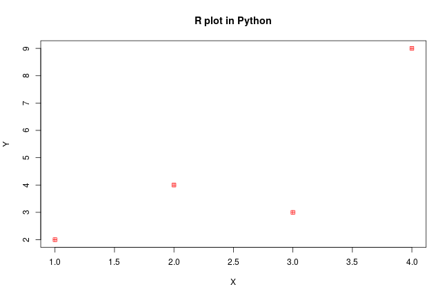

```python
%%R -w 9 -h 6 -u in

plot(X, Y, col='red', pch=12, main='R plot in Python')
```

# Linux Commands

Any command that works at the command-line can be used in IPython by prefixing it with the ! character. For example,

```python
!ls ../
```

```
datasets  jupyter_notes
```

```python
!pwd
```

```
/mnt/c/users/ychen/Desktop/Work/Allegis/Data Science/S140619_Data Science Tool Kits/Notebook_Demo/jupyter_notes
```

```python
# mix Linux Commands and Python Codes
directory = !pwd
print(directory)
```

```
['/mnt/c/users/ychen/Desktop/Work/Allegis/Data Science/S140619_Data Science Tool Kits/Notebook_Demo/jupyter_notes']
```

**if you play with IPython's shell commands for a while, you might notice that you cannot use !cd to navigate the filesystem:**

```python
!pwd
!cd ..
!pwd
```

```
/mnt/c/users/ychen/Desktop/Work/Allegis/Data Science/S140619_Data Science Tool Kits/Notebook_Demo
/mnt/c/users/ychen/Desktop/Work/Allegis/Data Science/S140619_Data Science Tool Kits/Notebook_Demo
```

The reason is that shell commands in the notebook are executed in a temporary subshell. If you'd like to change the working directory in a more enduring way, you can use the %cd magic command:

```python
!pwd
%cd ..
!pwd
```

```
/mnt/c/users/ychen/Desktop/Work/Allegis/Data Science/S140619_Data Science Tool Kits/Notebook_Demo
/mnt/c/users/ychen/Desktop/Work/Allegis/Data Science/S140619_Data Science Tool Kits
/mnt/c/users/ychen/Desktop/Work/Allegis/Data Science/S140619_Data Science Tool Kits
```

This is known as an automagic function, and this behavior can be toggled with the %automagic magic function.

# Snippets as Templates

**Snippets allow me to save time typing and keep things consistent.**

For example:

[figure not shown]

With Snippets manu, you can fill a cell with a lot of pre-defined snippets. For example

[figure not shown]

Then you can get the new cell added with pre-filled snippet for "Read from CSV" like below:

```python
bp_data = pd.read_csv("path/to/file.csv", header=1, delim_whitespace=True)
```